# Variance of Reasons for Stopping Requirements Analysis

Julian Frattini

2026-04-21

This notebook contains the analysis of the variance across demographic factors of responses to the question “Stated below are possible reasons for stopping the requirements analysis process and producing a requirements specification, capturing only what is known at the moment. Indicate your level of agreement or disagreement with the applicability of the reasons to your project.” The question requires rating the following statements:

| Code | Name | Text |
| --- | --- | --- |
| v_559 | Project terminated | The entire project was terminated. |
| v_560 | Scheduled end | The project plan says that now is the scheduled end of requirements analysis. |
| v_561 | Lead decided enough time spent | The project leader decided that we have spent enough time on requirements analysis. |
| v_562 | Lead decided enough time wasted | The project leader decided that we have wasted enough time on requirements analysis. |
| v_563 | Lead decided time pressure | The project leader decided that if we don’t start implementation now, we would not finish implementation in time. |
| v_564 | Team agreed enough time spent | The project members collectively agreed that we have spent enough time on requirements analysis. |
| v_565 | Team agreed enough time wasted | The project members collectively agreed that we have wasted enough time on requirements analysis. |
| v_566 | Team agreed time pressure | The project members collectively agreed that if we don’t start implementation now, we would not finish implementation in time. |
| v_567 | Itching to start implementation | We were just itching to get started on the implementation. |
| v_568 | Wasted enough time | We’ve wasted enough time just thinking and writing prose. |
| v_569 | Starting real work | It’s time to get started on the real work. |

All questions were answered on the following ordinal scale: Strongly disagree, Disagree, No opinion, Agree, Strongly agree

```r
# short name of the question
q = "reasons for stopping the requirements analysis"
# list of variables representing the statements for the question
v <- c("v_559", "v_560", "v_561", "v_562", "v_563", "v_564", "v_565", "v_566",
       "v_567", "v_568", "v_569")
# names of the variables
labels <- c("Project terminated", "Scheduled end",
            "Lead decided enough time spent", "Lead decided enough time wasted", "Lead decided time pressure",
            "Team agreed enough time spent", "Team agreed enough time wasted", "Team agreed time pressure",
            "Itching to start implementation", "Wasted enough time", "Starting real work")
# names of the options
options <- c("Strongly disagree", "Disagree", "No opinion", "Agree", "Strongly Agree")

# minimum likelihood of responses to be considered "common"
level.common <- 0.2
```

## Variables

We consider the following demographic factors:

| Code | Name | Question | Type |
| --- | --- | --- | --- |
| `v_23` | country | In which country are you personally located? | categorical |
| `v_3` | size | How many people are involved in your project? | numeric |
| `v_457` | way of working | How would you personally characterise the way your project works? | ordinal |
| `v_1` | sector | Please select the main industrial sector of your project or the application domain of the software you build. | categorical |
| `v_16` | external | Does your project involve external partners? | binary |
| `v_357` | distributed | Is your project distributed? | binary |
| `v_377` | virtualization | Do you tend to work from home, on-site, or both? | ordinal |
| `v_17` | role | What is the main role you occupy in your project? | categorical |

## Data Analysis

We analyze the variance of the response variable following established practices of Bayesian data analysis.[^1]

```r
d <- load_data_2024(data_path = "../../data", file = "data_preprocessed.csv") %>%
  select(
    "lfdn", # respondent identifier
    "v_3", "Country", "v_1", "v_457", "v_16", "v_357", "v_377", "v_17", # demographic factors
    all_of(v) # response variables
    ) %>%
  drop_na()

str(d)
```

```
## 'data.frame':    277 obs. of  20 variables:
##  $ lfdn   : int  100 102 104 106 108 109 111 115 117 119 ...
##  $ v_3    : int  20 5 8 20 25 25 7 20 6 5 ...
##  $ Country: chr  "Germany" "Sweden" "Germany" "Sweden" ...
##  $ v_1    : Factor w/ 22 levels "Agriculture",..: 5 2 6 12 6 15 2 10 17 17 ...
##  $ v_457  : Ord.factor w/ 6 levels "Agile"<"Rather agile"<..: 5 1 3 2 1 4 5 1 4 2 ...
##  $ v_16   : Factor w/ 3 levels "Yes","No","I don't know": 1 2 1 2 1 1 2 1 2 1 ...
##  $ v_357  : logi  TRUE FALSE TRUE FALSE TRUE TRUE ...
##  $ v_377  : Ord.factor w/ 6 levels "Almost completely on-site"<..: 3 1 3 2 1 5 3 4 3 2 ...
##  $ v_17   : Factor w/ 12 levels "Business Analyst",..: 12 3 4 11 5 8 4 1 3 11 ...
##  $ v_559  : Ord.factor w/ 5 levels "Strongly disagree"<..: 5 2 3 3 5 4 1 5 4 3 ...
##  $ v_560  : Ord.factor w/ 5 levels "Strongly disagree"<..: 2 2 2 3 1 4 1 2 2 4 ...
##  $ v_561  : Ord.factor w/ 5 levels "Strongly disagree"<..: 2 2 4 3 1 2 1 2 2 4 ...
##  $ v_562  : Ord.factor w/ 5 levels "Strongly disagree"<..: 1 3 2 3 1 2 1 1 1 4 ...
##  $ v_563  : Ord.factor w/ 5 levels "Strongly disagree"<..: 2 3 4 3 2 2 1 2 3 4 ...
##  $ v_564  : Ord.factor w/ 5 levels "Strongly disagree"<..: 2 3 4 3 2 2 1 2 3 4 ...
##  $ v_565  : Ord.factor w/ 5 levels "Strongly disagree"<..: 1 3 4 3 1 2 1 1 1 4 ...
##  $ v_566  : Ord.factor w/ 5 levels "Strongly disagree"<..: 4 3 2 3 2 3 1 2 2 4 ...
##  $ v_567  : Ord.factor w/ 5 levels "Strongly disagree"<..: 4 3 3 3 4 1 1 2 2 4 ...
##  $ v_568  : Ord.factor w/ 5 levels "Strongly disagree"<..: 1 3 2 3 2 1 2 1 4 4 ...
##  $ v_569  : Ord.factor w/ 5 levels "Strongly disagree"<..: 4 3 3 3 1 1 2 1 2 4 ...
```

For each outcome variable, we train one Bayesian regression model on all demographic variables as predictors.

### Modelling

First, we define a formula regressing the outcome variable of interest on the demographic factors

```r
f <-
  eval(parse(text = paste0("bf(mvbind(",
                           paste(v, collapse = ", "),
                           ") ~ 1 + v_3 + Country + v_1 + v_457 + v_16 + v_357 + v_377 + v_17)",
                           "+ set_rescor(FALSE)")))

# get_prior(f, data = d, family = cumulative("probit"))
```

For each coefficient implied by a predictor, we specify a prior based on domain knowledge.

```r
p <- c(
  set_prior("normal(0, 1)", class = "Intercept", resp = gsub("_", "", v)),
  set_prior("normal(0, 0.2)", class = "b", resp = gsub("_", "", v))
)
```

Since the response variables are all on the same ordinal scale, we model them using a multivariate cumulative distrubition utilizing a probit link to the parameter space of $p$.

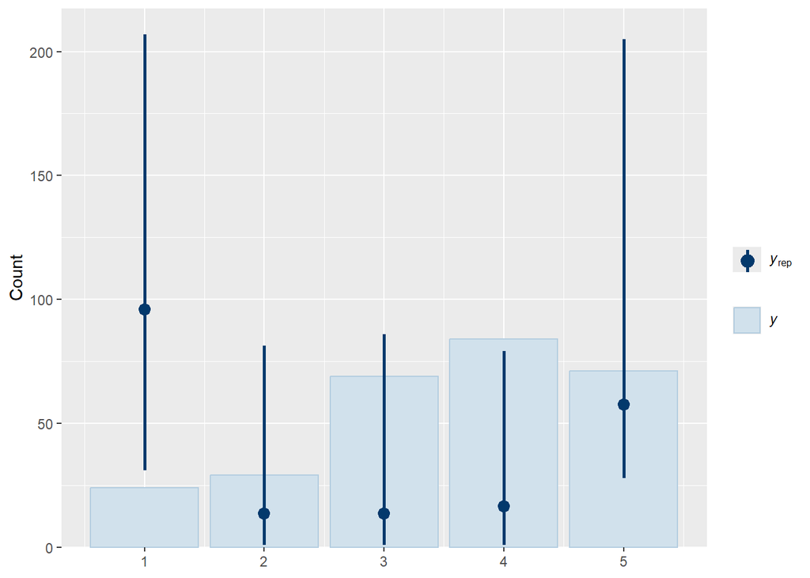

```r
m.prior <-
  brm(data = d, family = cumulative("probit"), formula = f, prior = p,
    iter = 2000, warmup = 1000, chains = 4, cores = 4,
    seed = 4, sample_prior="only",
    file = paste0("../fits/variance.", v[1], ".prior"), file_refit = "on_change"
  )

brms::pp_check(m.prior, ndraws=100, type = "bars", resp = gsub("_", "", v[1]))
```

The prior predictive check (for one of the response variable options) confirms the plausibility of the selected prior probability distribution. Given the number of predictors, the weight towards the extreme values is anticipated. Next, we update the coefficient distributions in light of the collected data using Monte Carlo Markov Chain sampling.

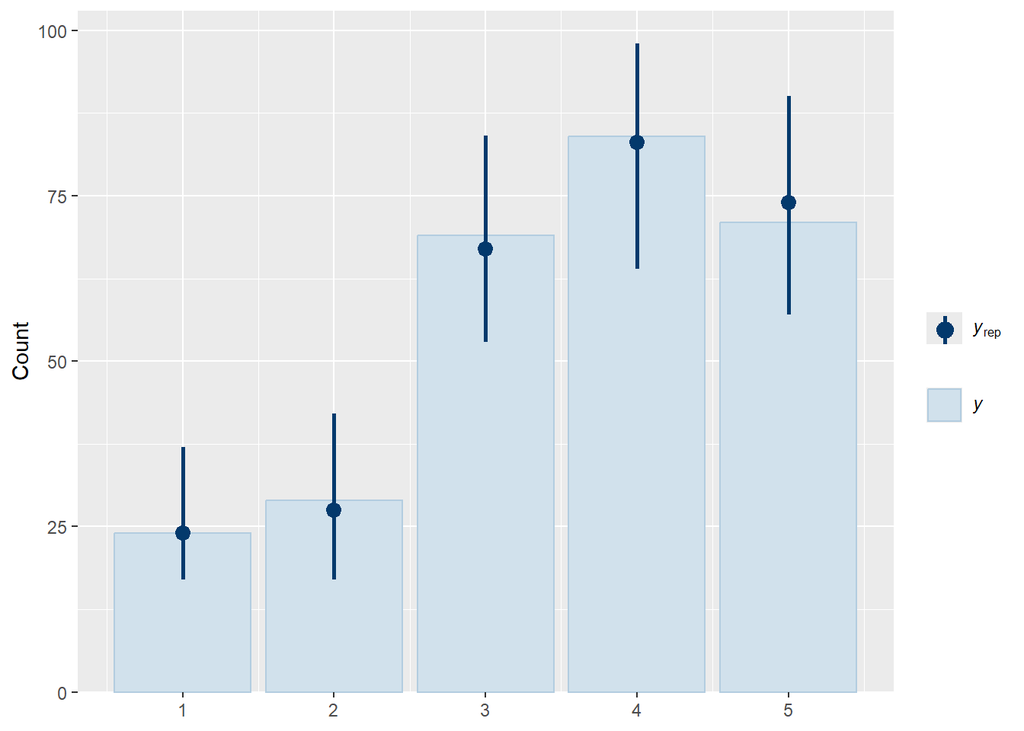

```r
m <-
  brm(data = d, family = cumulative("probit"), formula = f, prior = p,
    iter = 2000, warmup = 1000, chains = 4, cores = 4, seed = 4, init = 0,
    file = paste0("../fits/variance.", v[1]), file_refit = "on_change"
  )

brms::pp_check(m, ndraws=100, type="bars", resp = gsub("_", "", v[1]))
```

The posterior predictive check (for one of the response variable options) shows that the model predictions ($y_{rep}$) have grown closer to the actually observed data (`y`). This confirms that the model has trained well.

### Evaluation

We visualize the marginal effect of each demographic factor on every response option to determine, (1) whether an option can be viewed as “common”, and (2) whether the levels of the demographic factor affect the responses to this question.

```r
tabulate_common <- function(ceff, var, options) {
  # create a table containing a mapping of the statements to the response options where the CI is common
  result <- ceff %>%
    filter(lower__ > level.common) %>% # keep results where the lower bound of the CI is above the "common" level
    select(effect1__, effect2__, response) %>%
    group_by(response, effect2__) %>%
    filter(n_distinct(effect1__) == nrow(unique(select(d, var)))) %>% # keep only response x option combinations where all levels of the demographic factor are present (and, therefore, common)
    distinct(response, effect2__) %>%
    ungroup() %>%
    rename(all_of(c(Statement = "response", Option = "effect2__"))) %>%
    mutate(present = TRUE) %>%
    complete(
      Statement,
      Option = cat.likert,
      fill = list(present = FALSE)
    ) %>%
    mutate(Option = factor(Option, levels = cat.likert, ordered = TRUE) ) %>%
    pivot_wider(names_from = Option, values_from = present, values_fill = FALSE) %>%
    select(Statement, all_of(cat.likert))

  # Pre-compute which rows have at least one TRUE
  option_cols <- 2:(length(options)+1)
  has_any_true <- rowSums(result[, option_cols]) > 0

  tbl <- result |> kbl(align = "c")

  for (col_idx in option_cols) {
    tbl <- tbl |>
      column_spec(
        col_idx,
        background = case_when(
          !has_any_true          ~ "#d9d9d9",  # grey for all-FALSE rows
          result[[col_idx]]      ~ "#c6efce",  # green for TRUE cells
          .default               = "#ffc7ce"   # red for FALSE cells in active rows
        ),
        color = case_when(
          !has_any_true          ~ "#666666",  # muted text for grey rows
          result[[col_idx]]      ~ "#276221",  # dark green text
          .default               = "#9c0006"   # dark red text
        )
      )
  }

  tbl |> kable_styling(bootstrap_options = c("hover", "condensed"),
                       full_width = FALSE)
}
```

#### Sector

First, we investigate the effect of the sector (`v_1`) on all response options. The following table lists all options where the credibility interval was consistently above the level determined to indicate a “common” response.

```r
ceff.v1 <- conditional_effects(m, "v_1", categorical = TRUE, prob = 0.95) %>%
  purrr::imap_dfr( ~ {
    purrr::map_dfr(.x, identity) %>%
      mutate(response = str_extract(.y, "^[^.]+"))
  }) %>%
  mutate(
    response = factor(response, levels = gsub("_", "", v),
                      labels = labels, ordered = TRUE),
    effect2__ = factor(effect2__, levels = options, ordered = TRUE)
  )

tabulate_common(ceff.v1, "v_1", cat.likert)
```

| Statement | Strongly disagree | Disagree | No opinion | Agree | Strongly Agree |
| --- | --- | --- | --- | --- | --- |
| Project terminated | FALSE | FALSE | FALSE | FALSE | FALSE |
| Scheduled end | FALSE | FALSE | FALSE | FALSE | FALSE |
| Lead decided enough time spent | FALSE | TRUE | FALSE | FALSE | FALSE |
| Lead decided enough time wasted | FALSE | TRUE | FALSE | FALSE | FALSE |
| Lead decided time pressure | FALSE | FALSE | FALSE | FALSE | FALSE |
| Team agreed enough time spent | FALSE | FALSE | FALSE | FALSE | FALSE |
| Team agreed enough time wasted | FALSE | TRUE | FALSE | FALSE | FALSE |
| Team agreed time pressure | FALSE | FALSE | FALSE | FALSE | FALSE |
| Itching to start implementation | FALSE | FALSE | TRUE | FALSE | FALSE |
| Wasted enough time | FALSE | FALSE | FALSE | FALSE | FALSE |
| Starting real work | FALSE | FALSE | FALSE | FALSE | FALSE |

The following plot visualizes the marginal effect of the demographic factor on the response options per statement.

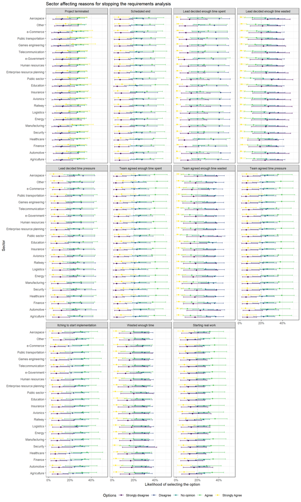

```r
ggplot(ceff.v1, aes(y = effect1__, color = effect2__)) +
  geom_point(aes(x = estimate__), position = position_dodge(width = 0.4)) +
  geom_errorbar(aes(xmin = lower__, xmax = upper__), position = position_dodge(width = 0.4)) +
  geom_vline(xintercept = level.common, color = "grey", linetype = "dashed") +
  facet_wrap(~response) +
  scale_x_continuous(labels = scales::percent) +
  labs(x = "Likelihood of selecting the option", y = "Sector", color = "Options") +
  ggtitle(paste0("Sector affecting ", q)) +
  theme_bw() +
  theme(legend.position = "bottom")
```

#### Project Size

Next, we investigate the effect of the the project size (`v_3`) on all response options.

```r
ceff.v3 <- conditional_effects(m, "v_3", categorical = TRUE, prob = 0.95) %>%
  purrr::imap_dfr( ~ {
    purrr::map_dfr(.x, identity) %>%
      mutate(response = str_extract(.y, "^[^.]+"))
  }) %>%
  mutate(
    response = factor(response, levels = gsub("_", "", v),
                      labels = labels, ordered = TRUE),
    effect2__ = factor(effect2__, levels = options, ordered = TRUE)
  )
```

The following plot visualizes the marginal effect of the demographic factor on the response options per statement.

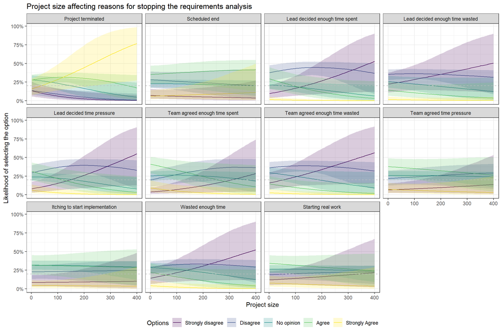

```r
ggplot(ceff.v3, aes(x = effect1__)) +
    geom_line(aes(y = estimate__, color = effect2__)) +
    geom_ribbon(aes(ymin = lower__, ymax = upper__, fill = effect2__), alpha = 0.2) +
    geom_hline(yintercept = level.common, color = "grey", linetype = "dashed") +
    facet_wrap(~response) +
    labs(x = "Project size", y = "Likelihood of selecting the option",
         color = "Options" , fill = "Options") +
    scale_y_continuous(labels = scales::percent) +
    ggtitle(paste0("Project size affecting ", q)) +
    theme_bw() +
    theme(legend.position = "bottom")
```

The following table lists all options where the credibility interval was consistently above the level determined to indicate a “common” response. When focusing on the range [1; 100] (instead of [1; 400]), we are only interested in the first 25 levels of the size factor (since the marginal effect, by default, samples 100 levels from the maximum range of the variable).

```r
ceff.v3 %>%
  filter(v_3 <= 100) %>%
  filter(lower__ > level.common) %>%
  select(effect1__, effect2__, response) %>%
  group_by(response, effect2__) %>%
  filter(
    # find all response x effect2__ pairs where all 25 levels of effect1__
    # (i.e., the project size) are above the level.common threshold,
    # i.e., have not been filtered out
    n_distinct(effect1__) == 25
  ) %>%
  distinct(response, effect2__) %>%
  ungroup() %>%
  rename(all_of(c(Statement = "response", Option = "effect2__")))
```

```
## # A tibble: 7 × 2
##   Statement                       Option
##   <ord>                           <ord>
## 1 Scheduled end                   Agree
## 2 Lead decided enough time spent  Disagree
## 3 Lead decided enough time wasted Disagree
## 4 Team agreed enough time wasted  Disagree
## 5 Team agreed time pressure       Agree
## 6 Itching to start implementation No opinion
## 7 Starting real work              No opinion
```

#### Country

Next, we investigate the effect of the the country (`Country`) on all response options. The following table lists all options where the credibility interval was consistently above the level determined to indicate a “common” response.

```r
ceff.country <- conditional_effects(m, "Country", categorical = TRUE, prob = 0.95) %>%
  purrr::imap_dfr( ~ {
    purrr::map_dfr(.x, identity) %>%
      mutate(response = str_extract(.y, "^[^.]+"))
  }) %>%
  mutate(
    response = factor(response, levels = gsub("_", "", v),
                      labels = labels, ordered = TRUE),
    effect2__ = factor(effect2__, levels = options, ordered = TRUE)
  )

tabulate_common(ceff.country, "Country", cat.likert)
```

| Statement | Strongly disagree | Disagree | No opinion | Agree | Strongly Agree |
| --- | --- | --- | --- | --- | --- |
| Project terminated | FALSE | FALSE | FALSE | FALSE | FALSE |
| Scheduled end | FALSE | FALSE | FALSE | FALSE | FALSE |
| Lead decided enough time spent | FALSE | TRUE | FALSE | FALSE | FALSE |
| Lead decided enough time wasted | FALSE | TRUE | FALSE | FALSE | FALSE |
| Lead decided time pressure | FALSE | FALSE | FALSE | FALSE | FALSE |
| Team agreed enough time spent | FALSE | FALSE | FALSE | TRUE | FALSE |
| Team agreed enough time wasted | FALSE | TRUE | FALSE | FALSE | FALSE |
| Team agreed time pressure | FALSE | FALSE | FALSE | FALSE | FALSE |
| Itching to start implementation | FALSE | FALSE | TRUE | FALSE | FALSE |
| Wasted enough time | FALSE | FALSE | FALSE | FALSE | FALSE |
| Starting real work | FALSE | FALSE | FALSE | FALSE | FALSE |

The following plot visualizes the marginal effect of the demographic factor on the response options per statement.

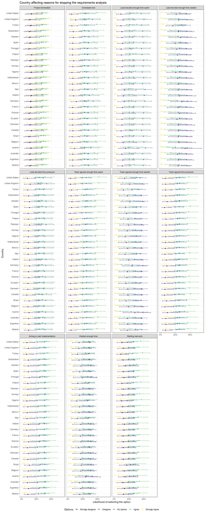

```r
ggplot(ceff.country, aes(y = effect1__, color = effect2__)) +
  geom_point(aes(x = estimate__), position = position_dodge(width = 0.4)) +
  geom_errorbar(aes(xmin = lower__, xmax = upper__), position = position_dodge(width = 0.4)) +
  geom_vline(xintercept = level.common, color = "grey", linetype = "dashed") +
  facet_wrap(~response) +
  scale_x_continuous(labels = scales::percent) +
  labs(x = "Likelihood of selecting the option", y = "Country", color = "Options") +
  ggtitle(paste0("Country affecting ", q)) +
  theme_bw() +
  theme(legend.position = "bottom")
```

#### Way-of-Working

Next, we investigate the effect of the way-of-working (`v_457`) on all response options. The following table lists all options where the credibility interval was consistently above the level determined to indicate a “common” response.

```r
ceff.v457 <- conditional_effects(m, "v_457", categorical = TRUE, prob = 0.95) %>%
  purrr::imap_dfr( ~ {
    purrr::map_dfr(.x, identity) %>%
      mutate(response = str_extract(.y, "^[^.]+"))
  }) %>%
  mutate(
    response = factor(response, levels = gsub("_", "", v),
                      labels = labels, ordered = TRUE),
    effect2__ = factor(effect2__, levels = options, ordered = TRUE)
  )

tabulate_common(ceff.v457, "v_457", cat.likert)
```

| Statement | Strongly disagree | Disagree | No opinion | Agree | Strongly Agree |
| --- | --- | --- | --- | --- | --- |
| Project terminated | FALSE | FALSE | FALSE | FALSE | FALSE |
| Scheduled end | FALSE | FALSE | FALSE | FALSE | FALSE |
| Lead decided enough time spent | FALSE | TRUE | FALSE | FALSE | FALSE |
| Lead decided enough time wasted | FALSE | TRUE | FALSE | FALSE | FALSE |
| Lead decided time pressure | FALSE | FALSE | FALSE | FALSE | FALSE |
| Team agreed enough time spent | FALSE | FALSE | FALSE | FALSE | FALSE |
| Team agreed enough time wasted | FALSE | TRUE | FALSE | FALSE | FALSE |
| Team agreed time pressure | FALSE | FALSE | FALSE | FALSE | FALSE |
| Itching to start implementation | FALSE | FALSE | TRUE | FALSE | FALSE |
| Wasted enough time | FALSE | FALSE | TRUE | FALSE | FALSE |
| Starting real work | FALSE | FALSE | TRUE | FALSE | FALSE |

The following plot visualizes the marginal effect of the demographic factor on the response options per statement.

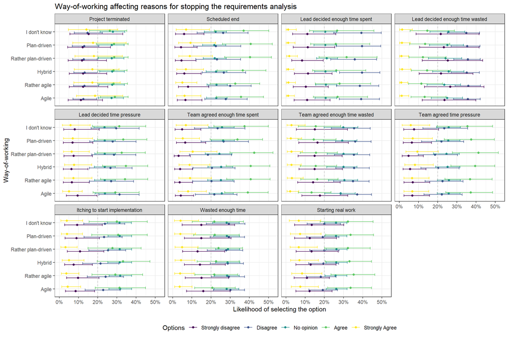

```r
ggplot(ceff.v457, aes(y = effect1__, color = effect2__)) +
  geom_point(aes(x = estimate__), position = position_dodge(width = 0.4)) +
  geom_errorbar(aes(xmin = lower__, xmax = upper__), position = position_dodge(width = 0.4)) +
  geom_vline(xintercept = level.common, color = "grey", linetype = "dashed") +
  facet_wrap(~response) +
  scale_x_continuous(labels = scales::percent) +
  labs(x = "Likelihood of selecting the option", y = "Way-of-working", color = "Options") +
  ggtitle(paste0("Way-of-working affecting ", q)) +
  theme_bw() +
  theme(legend.position = "bottom")
```

#### External Partners

Next, we investigate the effect of whether or not the project includes external partners (`v_16`) on all response options. The following table lists all options where the credibility interval was consistently above the level determined to indicate a “common” response.

```r
ceff.v16 <- conditional_effects(m, "v_16", categorical = TRUE, prob = 0.95) %>%
  purrr::imap_dfr( ~ {
    purrr::map_dfr(.x, identity) %>%
      mutate(response = str_extract(.y, "^[^.]+"))
  }) %>%
  mutate(
    response = factor(response, levels = gsub("_", "", v),
                      labels = labels, ordered = TRUE),
    effect2__ = factor(effect2__, levels = options, ordered = TRUE)
  )

tabulate_common(ceff.v16, "v_16", cat.likert)
```

| Statement | Strongly disagree | Disagree | No opinion | Agree | Strongly Agree |
| --- | --- | --- | --- | --- | --- |
| Project terminated | FALSE | FALSE | FALSE | FALSE | FALSE |
| Scheduled end | FALSE | FALSE | FALSE | TRUE | FALSE |
| Lead decided enough time spent | FALSE | TRUE | FALSE | FALSE | FALSE |
| Lead decided enough time wasted | FALSE | TRUE | FALSE | FALSE | FALSE |
| Lead decided time pressure | FALSE | FALSE | FALSE | FALSE | FALSE |
| Team agreed enough time spent | FALSE | FALSE | FALSE | TRUE | FALSE |
| Team agreed enough time wasted | FALSE | TRUE | FALSE | FALSE | FALSE |
| Team agreed time pressure | FALSE | FALSE | FALSE | FALSE | FALSE |
| Itching to start implementation | FALSE | FALSE | TRUE | FALSE | FALSE |
| Wasted enough time | FALSE | FALSE | TRUE | FALSE | FALSE |
| Starting real work | FALSE | FALSE | FALSE | TRUE | FALSE |

The following plot visualizes the marginal effect of the demographic factor on the response options per statement.

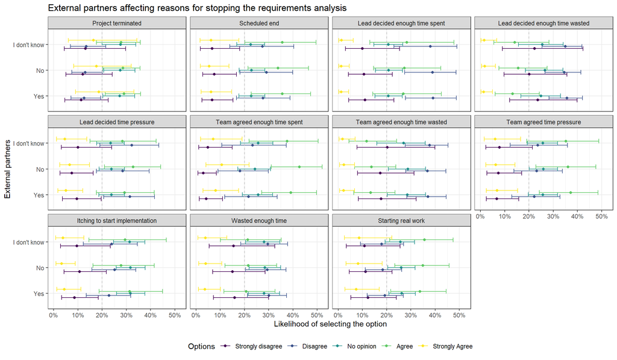

```r
ggplot(ceff.v16, aes(y = effect1__, color = effect2__)) +
  geom_point(aes(x = estimate__), position = position_dodge(width = 0.4)) +
  geom_errorbar(aes(xmin = lower__, xmax = upper__), position = position_dodge(width = 0.4)) +
  geom_vline(xintercept = level.common, color = "grey", linetype = "dashed") +
  facet_wrap(~response) +
  scale_x_continuous(labels = scales::percent) +
  labs(x = "Likelihood of selecting the option", y = "External partners", color = "Options") +
  ggtitle(paste0("External partners affecting ", q)) +
  theme_bw() +
  theme(legend.position = "bottom")
```

#### Distributed

Next, we investigate the effect of whether or not the project is distributed (`v_357`) on all response options. The following table lists all options where the credibility interval was consistently above the level determined to indicate a “common” response.

```r
ceff.v357 <- conditional_effects(m, "v_357", categorical = TRUE, prob = 0.95) %>%
  purrr::imap_dfr( ~ {
    purrr::map_dfr(.x, identity) %>%
      mutate(response = str_extract(.y, "^[^.]+"))
  }) %>%
  mutate(
    response = factor(response, levels = gsub("_", "", v),
                      labels = labels, ordered = TRUE),
    effect2__ = factor(effect2__, levels = options, ordered = TRUE)
  )

tabulate_common(ceff.v357, "v_357", cat.likert)
```

| Statement | Strongly disagree | Disagree | No opinion | Agree | Strongly Agree |
| --- | --- | --- | --- | --- | --- |
| Project terminated | FALSE | FALSE | FALSE | TRUE | FALSE |
| Scheduled end | FALSE | FALSE | FALSE | TRUE | FALSE |
| Lead decided enough time spent | FALSE | TRUE | FALSE | FALSE | FALSE |
| Lead decided enough time wasted | FALSE | TRUE | FALSE | FALSE | FALSE |
| Lead decided time pressure | FALSE | FALSE | FALSE | FALSE | FALSE |
| Team agreed enough time spent | FALSE | FALSE | FALSE | TRUE | FALSE |
| Team agreed enough time wasted | FALSE | TRUE | FALSE | FALSE | FALSE |
| Team agreed time pressure | FALSE | FALSE | FALSE | TRUE | FALSE |
| Itching to start implementation | FALSE | FALSE | TRUE | FALSE | FALSE |
| Wasted enough time | FALSE | TRUE | TRUE | FALSE | FALSE |
| Starting real work | FALSE | FALSE | TRUE | TRUE | FALSE |

The following plot visualizes the marginal effect of the demographic factor on the response options per statement.

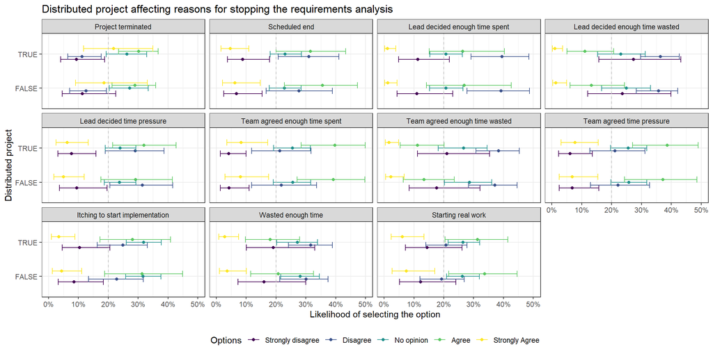

```r
ggplot(ceff.v357, aes(y = effect1__, color = effect2__)) +
  geom_point(aes(x = estimate__), position = position_dodge(width = 0.4)) +
  geom_errorbar(aes(xmin = lower__, xmax = upper__), position = position_dodge(width = 0.4)) +
  geom_vline(xintercept = level.common, color = "grey", linetype = "dashed") +
  facet_wrap(~response) +
  scale_x_continuous(labels = scales::percent) +
  labs(x = "Likelihood of selecting the option", y = "Distributed project", color = "Options") +
  ggtitle(paste0("Distributed project affecting ", q)) +
  theme_bw() +
  theme(legend.position = "bottom")
```

#### Degree of Virtualization

Next, we investigate the effect of the degree of virtualization (`v_377`) on all response options. The following table lists all options where the credibility interval was consistently above the level determined to indicate a “common” response.

```r
ceff.v377 <- conditional_effects(m, "v_377", categorical = TRUE, prob = 0.95) %>%
  purrr::imap_dfr( ~ {
    purrr::map_dfr(.x, identity) %>%
      mutate(response = str_extract(.y, "^[^.]+"))
  }) %>%
  mutate(
    response = factor(response, levels = gsub("_", "", v),
                      labels = labels, ordered = TRUE),
    effect2__ = factor(effect2__, levels = options, ordered = TRUE)
  )

tabulate_common(ceff.v377, "v_377", cat.likert)
```

| Statement | Strongly disagree | Disagree | No opinion | Agree | Strongly Agree |
| --- | --- | --- | --- | --- | --- |
| Project terminated | FALSE | FALSE | FALSE | TRUE | FALSE |
| Scheduled end | FALSE | FALSE | FALSE | FALSE | FALSE |
| Lead decided enough time spent | FALSE | TRUE | FALSE | FALSE | FALSE |
| Lead decided enough time wasted | FALSE | TRUE | FALSE | FALSE | FALSE |
| Lead decided time pressure | FALSE | FALSE | FALSE | FALSE | FALSE |
| Team agreed enough time spent | FALSE | FALSE | FALSE | TRUE | FALSE |
| Team agreed enough time wasted | FALSE | TRUE | FALSE | FALSE | FALSE |
| Team agreed time pressure | FALSE | FALSE | FALSE | TRUE | FALSE |
| Itching to start implementation | FALSE | FALSE | TRUE | FALSE | FALSE |
| Wasted enough time | FALSE | TRUE | FALSE | FALSE | FALSE |
| Starting real work | FALSE | FALSE | TRUE | FALSE | FALSE |

The following plot visualizes the marginal effect of the demographic factor on the response options per statement.

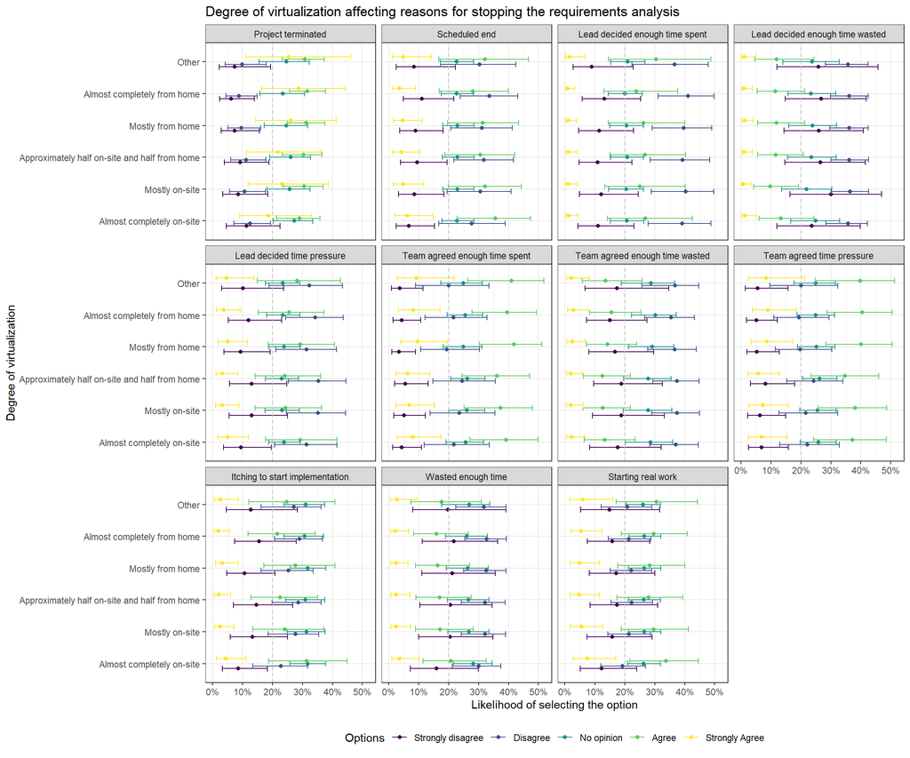

```r
ggplot(ceff.v377, aes(y = effect1__, color = effect2__)) +
  geom_point(aes(x = estimate__), position = position_dodge(width = 0.4)) +
  geom_errorbar(aes(xmin = lower__, xmax = upper__), position = position_dodge(width = 0.4)) +
  geom_vline(xintercept = level.common, color = "grey", linetype = "dashed") +
  facet_wrap(~response) +
  scale_x_continuous(labels = scales::percent) +
  labs(x = "Likelihood of selecting the option", y = "Degree of virtualization", color = "Options") +
  ggtitle(paste0("Degree of virtualization affecting ", q)) +
  theme_bw() +
  theme(legend.position = "bottom")
```

#### Main Role

Next, we investigate the effect of the main role of the participant (`v_17`) on all response options. The following table lists all options where the credibility interval was consistently above the level determined to indicate a “common” response.

```r
ceff.v17 <- conditional_effects(m, "v_17", categorical = TRUE, prob = 0.95) %>%
  purrr::imap_dfr( ~ {
    purrr::map_dfr(.x, identity) %>%
      mutate(response = str_extract(.y, "^[^.]+"))
  }) %>%
  mutate(
    response = factor(response, levels = gsub("_", "", v),
                      labels = labels, ordered = TRUE),
    effect2__ = factor(effect2__, levels = options, ordered = TRUE)
  )

tabulate_common(ceff.v17, "v_17", cat.likert)
```

| Statement | Strongly disagree | Disagree | No opinion | Agree | Strongly Agree |
| --- | --- | --- | --- | --- | --- |
| Project terminated | FALSE | FALSE | FALSE | FALSE | FALSE |
| Scheduled end | FALSE | FALSE | FALSE | FALSE | FALSE |
| Lead decided enough time spent | FALSE | TRUE | FALSE | FALSE | FALSE |
| Lead decided enough time wasted | FALSE | TRUE | FALSE | FALSE | FALSE |
| Lead decided time pressure | FALSE | FALSE | FALSE | FALSE | FALSE |
| Team agreed enough time spent | FALSE | FALSE | FALSE | FALSE | FALSE |
| Team agreed enough time wasted | FALSE | TRUE | FALSE | FALSE | FALSE |
| Team agreed time pressure | FALSE | FALSE | FALSE | FALSE | FALSE |
| Itching to start implementation | FALSE | FALSE | TRUE | FALSE | FALSE |
| Wasted enough time | FALSE | FALSE | FALSE | FALSE | FALSE |
| Starting real work | FALSE | FALSE | FALSE | FALSE | FALSE |

The following plot visualizes the marginal effect of the demographic factor on the response options per statement.

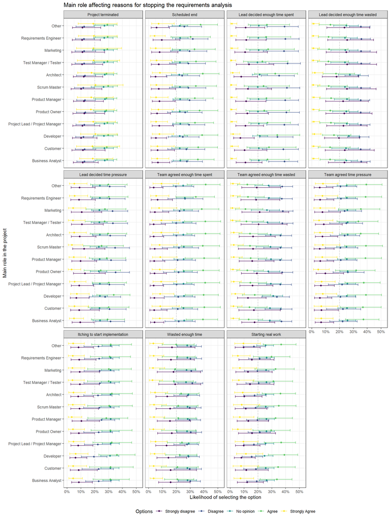

```r
ggplot(ceff.v17, aes(y = effect1__, color = effect2__)) +
  geom_point(aes(x = estimate__), position = position_dodge(width = 0.4)) +
  geom_errorbar(aes(xmin = lower__, xmax = upper__), position = position_dodge(width = 0.4)) +
  geom_vline(xintercept = level.common, color = "grey", linetype = "dashed") +
  facet_wrap(~response) +
  scale_x_continuous(labels = scales::percent) +
  labs(x = "Likelihood of selecting the option", y = "Main role in the project", color = "Options") +
  ggtitle(paste0("Main role affecting ", q)) +
  theme_bw() +
  theme(legend.position = "bottom")
```

[^1]: McElreath, R. (2018). Statistical rethinking: A Bayesian course with examples in R and Stan. Chapman and Hall/CRC.